# Read and operate geographic map data

**Created by**

¶ [Li, Chaonan (李超男)](https://www.researchgate.net/profile/Chaonan-Li-5) / licn@mtc.edu.cn / [Ecological Security and Protection Key Laboratory of Sichuan Province, Mianyang Normal University (绵阳师范学院生态安全与保护四川省重点实验室)](https://zdsys.mtc.edu.cn/)

¶ Liu Chi (刘驰) / liuchi0426@126.com / [College of Resources and Environment, Fujian Agriculture and Forestry University (福建农林大学资源与环境学院)](https://zhxy.fafu.edu.cn/main.htm)

¶ Liao, Haijun (廖海君) / lihj@mtc.edu.cn / [Engineering Research Center of Chuanxibei RHS Construction at Mianyang Normal University of Sichuan Province (绵阳师范学院川西北乡村人居环境建设工程研究中心)](https://rhs.mtc.edu.cn//)

**Reviewed by**

¶ [Li, Xiangzhen (李香真)](https://www.researchgate.net/profile/Xiangzhen-Li-2) / lixz@fafu.edu.cn / [College of Resources and Environment, Fujian Agriculture and Forestry University (福建农林大学资源与环境学院)](https://zhxy.fafu.edu.cn/main.htm)

The microgeo provides three functions to read geographic map data from online repositories or a local file. The `read_aliyun_map()` retrieves an area or multiple areas of China map from the [DataV.GeoAtlas](http://datav.aliyun.com/portal/school/atlas/area_selector). We just need to access the [DataV.GeoAtlas](http://datav.aliyun.com/portal/school/atlas/area_selector) to query one or multiple adcodes, and pass them as a parameter to `read_aliyun_map()`. This would allow us to obtain a microgeo-compatible and reliable SpatialPolygonsDataFrame. The `read_gadm_map()` and `read_shp_map()` are implemented to fetch geographic map data from the [Global Administrative Areas (GADM)](https://gadm.org) and a local ESRI Shapefile, respectively, based on the `geodata::gadm()` and `rgdal::readOGR()`. By using these functions, we are able to build a microgeo-compatible SpatialPolygonsDataFrame for any area in the world. Particularly, the SpatialPolygonsDataFrame returned by `read_gadm_map()` and `read_shp_map()` should be processed by `trans_map_fmt()`, which converts a non-standardized SpatialPolygonsDataFrame to a microgeo-compatible one.

The microgeo provides a function of `grid_map()`, which grids the map based on a given spatial resolution (degree). That is, the map of the whole study area can be divided into grids uniformly by applying such a function. The SpatialPolygonsDataFrame returned by `grid_map()` is the foundation of grid-based analysis and visualization in microgeo R package.

Now, let's go through each of these functions and see how they are used.

## Load required R packages

```r
# Load three required packages
suppressMessages(require("magrittr"))
require("ggplot2")  %>% suppressMessages()
require("microgeo") %>% suppressMessages()
#prev_locale <- Sys.setlocale("LC_CTYPE", "C.UTF-8") # Set locale to `UTF-8` to show Chinese characters in tables; for linux
```

## Read geographic map data from the [DataV.GeoAtlas](http://datav.aliyun.com/portal/school/atlas/area_selector)

The [DataV.GeoAtlas](http://datav.aliyun.com/portal/school/atlas/area_selector) (Aliyun, 阿里云) provides standardized and reliable map data of China. We have implemented a function of `read_aliyun_map()` for Mainland Chinese users to retrieve trustworthy map data from such a public repository. This function requires one or mutiple adcodes to download the map of our study area. For example, the '650000' represents Xinjiang, while the 'c(540000, 630000, 510000)' represents Xizang, Qinghai and Sichuan, respectively. We can use the [DataV.GeoAtlas](http://datav.aliyun.com/portal/school/atlas/area_selector) to query the adcodes for map areas. Here are some simple examples.

Firstly, we set `sub.area = TRUE`, which will include the sub boundary of each adcodes in the returned SpatialPolygonsDataFrame.

```r
# Read the map of Xizang, Qinghai and Sichuan
# The `read_aliyun_map` returns a microgeo-compatible and reliable SpatialPolygonsDataFrame
map1 <- read_aliyun_map(adcode = c(540000, 630000, 510000), sub.area = TRUE) %>% suppressMessages()
head(map1@data)
```

A data.frame: 6 × 5

|  | TYPE <chr> | FMTS <chr> | NAME <chr> | X.CENTER <dbl> | Y.CENTER <dbl> |
| --- | --- | --- | --- | --- | --- |
| 1 | DataV.GeoAtlas | microgeo | 拉萨市 | 91.09176 | 30.03707 |
| 2 | DataV.GeoAtlas | microgeo | 日喀则市 | 86.47785 | 29.49853 |
| 3 | DataV.GeoAtlas | microgeo | 昌都市 | 97.03518 | 30.78373 |
| 4 | DataV.GeoAtlas | microgeo | 林芝市 | 95.23930 | 29.19898 |
| 5 | DataV.GeoAtlas | microgeo | 山南市 | 92.26661 | 28.30393 |
| 6 | DataV.GeoAtlas | microgeo | 那曲市 | 89.24948 | 32.78340 |

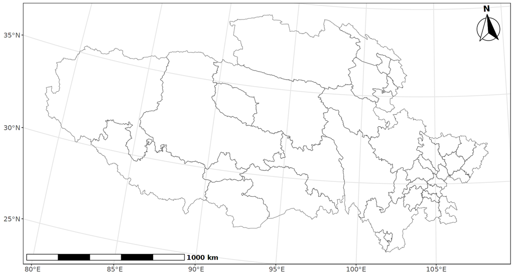

```r
# Plot the map of Xizang, Qinghai and Sichuan
options(repr.plot.width = 13.43, repr.plot.height = 7.23)
map1 %>% plot_bmap() %>% add_north_arrow() %>% add_scale_bar() %>% add_crs()
```

Then, we set `sub.area = FALSE` (default), which would not include the sub boundary of each adcodes in the returned SpatialPolygonsDataFrame.

```r
# Read the map of Xizang, Qinghai and Sichuan
# The `read_aliyun_map` returns a microgeo-compatible and reliable SpatialPolygonsDataFrame
map2 <- read_aliyun_map(adcode = c(540000, 630000, 510000), sub.area = FALSE)
head(map2@data)
```

A data.frame: 3 × 5

|  | TYPE <chr> | FMTS <chr> | NAME <chr> | X.CENTER <dbl> | Y.CENTER <dbl> |
| --- | --- | --- | --- | --- | --- |
| 1 | DataV.GeoAtlas | microgeo | 西藏自治区 | 88.38828 | 31.56375 |
| 2 | DataV.GeoAtlas | microgeo | 青海省 | 96.04353 | 35.72640 |
| 3 | DataV.GeoAtlas | microgeo | 四川省 | 102.69345 | 30.67454 |

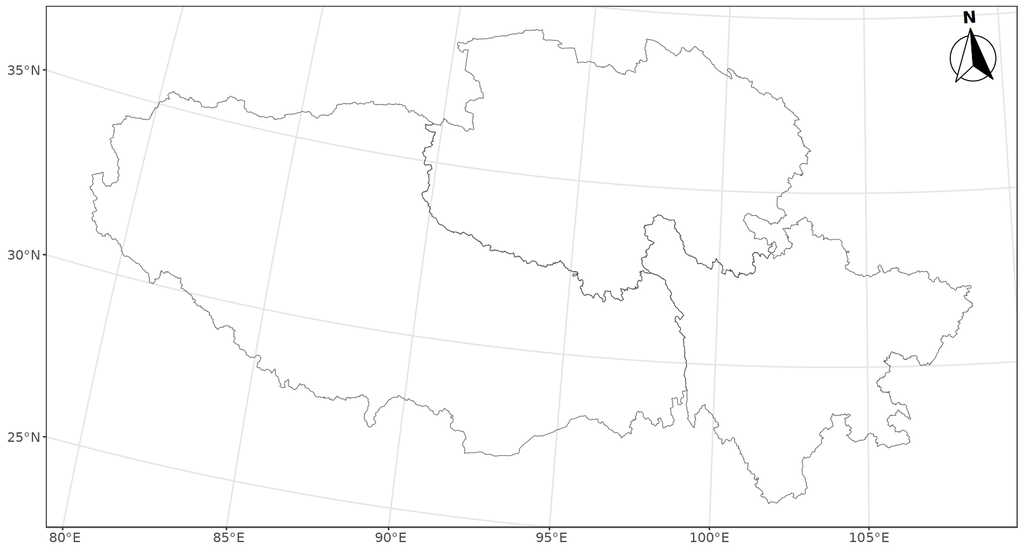

```r
# Plot the map of Xizang, Qinghai and Sichuan
options(repr.plot.width = 13.43, repr.plot.height = 7.23)
map2 %>% plot_bmap() %>% add_north_arrow() %>% add_crs()
```

## Read geographic map data from the [Global Administrative Areas (GADM)](https://gadm.org)

To expand the source of geographic map data, we also have implemented a function of `read_gadm_map()` based on the `geodata::gadm()`, which reads geographic map data from the [GADM](https://gadm.org/) for any area in the world. Particularly, the Chinese territorial claims are not reflected in the boundary data provided by the GADM, and the data for provincial/city/district boundaries may not necessarily be the most up-to-date versions. Thus, additional cautions should be exercised when publishing graphics that utilize GADM data in official publications. The author of microgeo R package is not responsible for any political disputes and instability caused by the use of this R package by anyone.

The SpatialPolygonsDataFrame returned by `read_gadm_map()` should be processed by `trans_map_fmt()` to convert the non-standardized SpatialPolygonsDataFrame to a microgeo-compatible one.

Firstly, we use the map of Australia as an example. Just run the following codes.

```r
# Read the map of Australia
map <- read_gadm_map(iso = 'Australia', out.dir = '../dev/dat/rundata')
head(map@data)
```

A data.frame: 6 × 10

|  | GID_0 <chr> | NAME_0 <chr> | GID_1 <chr> | NAME_1 <chr> | VARNAME_1 <chr> | NL_NAME_1 <chr> | TYPE_1 <chr> | ENGTYPE_1 <chr> | CC_1 <chr> | HASC_1 <chr> |
| --- | --- | --- | --- | --- | --- | --- | --- | --- | --- | --- |
| 1 | AUS | Australia | AUS.1_1 | Ashmore and Cartier Islands | NA | NA | Territory | Territory | 12 | AU.AS |
| 2 | AUS | Australia | AUS.2_1 | Australian Capital Territory | NA | NA | Territory | Territory | 8 | AU.AC |
| 3 | AUS | Australia | AUS.3_1 | Coral Sea Islands Territory | NA | NA | Territory | Territory | 11 | AU.CR |
| 4 | AUS | Australia | AUS.4_1 | Jervis Bay Territory | NA | NA | Territory | Territory | 10 | AU.JB |
| 5 | AUS | Australia | AUS.5_1 | New South Wales | NA | NA | State | State | 1 | AU.NS |
| 6 | AUS | Australia | AUS.6_1 | Northern Territory | NA | NA | Territory | Territory | 7 | AU.NT |

```r
# Convert the non-standardized SpatialPolygonsDataFrame to a microgeo-compatible one
map %<>% trans_map_fmt(var = 'NAME_1')
head(map@data)
```

A data.frame: 6 × 5

|  | TYPE <chr> | FMTS <chr> | NAME <chr> | X.CENTER <dbl> | Y.CENTER <dbl> |
| --- | --- | --- | --- | --- | --- |
| 1 | Non.DataV.GeoAtlas | microgeo | Ashmore and Cartier Islands | 123.1045 | -12.26562 |
| 2 | Non.DataV.GeoAtlas | microgeo | Australian Capital Territory | 149.0025 | -35.48881 |
| 3 | Non.DataV.GeoAtlas | microgeo | Coral Sea Islands Territory | 154.3975 | -20.99987 |
| 4 | Non.DataV.GeoAtlas | microgeo | Jervis Bay Territory | 150.6897 | -35.15280 |
| 5 | Non.DataV.GeoAtlas | microgeo | New South Wales | 147.0143 | -32.17578 |
| 6 | Non.DataV.GeoAtlas | microgeo | Northern Territory | 133.3700 | -19.47888 |

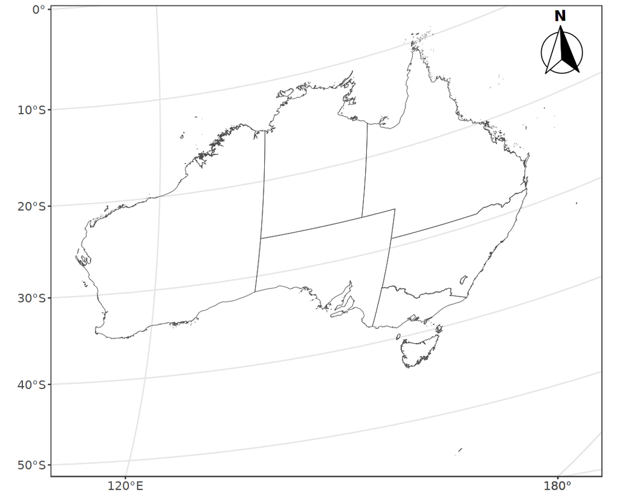

```r
# Visualize the map of Australia
options(repr.plot.width = 9, repr.plot.height = 7.23)
map %>% plot_bmap() %>% add_north_arrow() %>% add_crs()
```

Then, we use the map of Washington State, USA as an example. Just run the following codes.

```r
# Read the map of Washington State, USA
map <- read_gadm_map(iso = 'USA', out.dir = '../dev/dat/rundata')
head(map@data)
```

A data.frame: 6 × 10

|  | GID_0 <chr> | NAME_0 <chr> | GID_1 <chr> | NAME_1 <chr> | VARNAME_1 <chr> | NL_NAME_1 <chr> | TYPE_1 <chr> | ENGTYPE_1 <chr> | CC_1 <chr> | HASC_1 <chr> |
| --- | --- | --- | --- | --- | --- | --- | --- | --- | --- | --- |
| 1 | USA | United States | USA.1_1 | Alabama | AL\|Ala. | NA | State | State | NA | US.AL |
| 2 | USA | United States | USA.2_1 | Alaska | AK\|Alaska | NA | State | State | NA | US.AK |
| 3 | USA | United States | USA.3_1 | Arizona | AZ\|Ariz. | NA | State | State | NA | US.AZ |
| 4 | USA | United States | USA.4_1 | Arkansas | AR\|Ark. | NA | State | State | NA | US.AR |
| 5 | USA | United States | USA.5_1 | California | CA\|Calif. | NA | State | State | NA | US.CA |
| 6 | USA | United States | USA.6_1 | Colorado | CO\|Colo. | NA | State | State | NA | US.CO |

```r
# Get the areas of Washington, USA
map %<>% terra::subset(map$NAME_1 == 'Washington')
head(map@data)
```

A data.frame: 1 × 10

|  | GID_0 <chr> | NAME_0 <chr> | GID_1 <chr> | NAME_1 <chr> | VARNAME_1 <chr> | NL_NAME_1 <chr> | TYPE_1 <chr> | ENGTYPE_1 <chr> | CC_1 <chr> | HASC_1 <chr> |
| --- | --- | --- | --- | --- | --- | --- | --- | --- | --- | --- |
| 48 | USA | United States | USA.48_1 | Washington | WA\|Wash. | NA | State | State | NA | US.WA |

```r
# Convert the non-standardized SpatialPolygonsDataFrame to a microgeo-compatible one
map %<>% trans_map_fmt(var = 'NAME_1') # only use the map of Washington, USA
head(map@data)
```

A data.frame: 1 × 5

|  | TYPE <chr> | FMTS <chr> | NAME <chr> | X.CENTER <dbl> | Y.CENTER <dbl> |
| --- | --- | --- | --- | --- | --- |
| 48 | Non.DataV.GeoAtlas | microgeo | Washington | -120.4222 | 47.37641 |

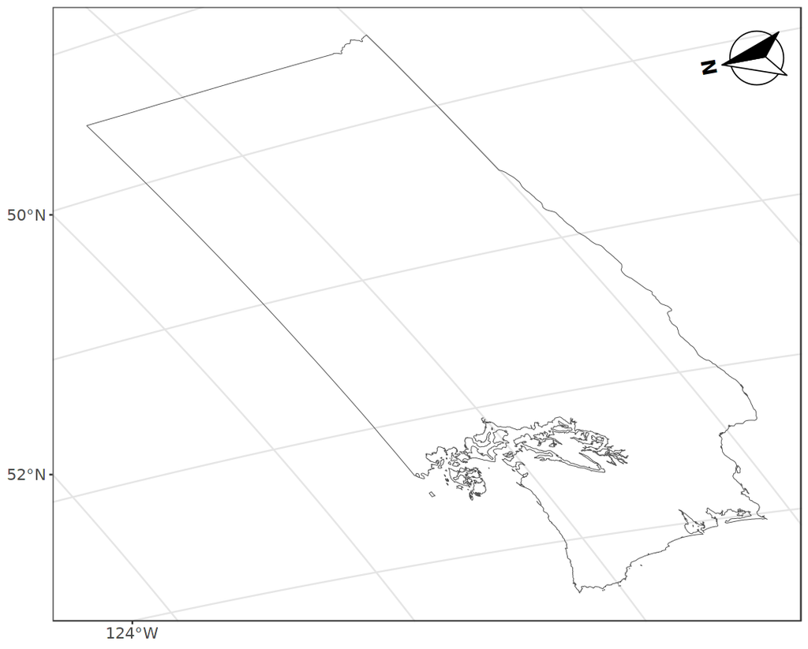

```r
# Visualize the map of Washington State, USA
options(repr.plot.width = 9, repr.plot.height = 7.23)
map %>% plot_bmap() %>% add_north_arrow() %>% add_crs()
```

## Read geographic map data from a ESRI Shapefile

If neither `read_aliyun_map()` nor `read_gadm_map()` meets your needs, there is another way to read geographic map data for using the microgeo R package. We have implemented a function of `read_shp_map()` based on the `rgdal::readOGR()`, which reads a ESRI Shapefile from your local computer disk (the ESRI Shapefile must be provided by yourself).

The SpatialPolygonsDataFrame returned by `read_shp_map()` should be processed by `trans_map_fmt()` to convert the non-standardized SpatialPolygonsDataFrame to a microgeo-compatible one.

Firstly, we use the sub-areas of China map loaded from a local ESRI Shapefile as an example.

```r
# Read original China map from local shapefiles
cn.map <- system.file("shapefiles/china-map", "china.shp", package = "microgeo") %>% read_shp_map() %>% suppressMessages()
head(cn.map@data)
```

A data.frame: 6 × 9

|  | AREA <dbl> | BOUND_A_ <int> | BOUND_A_ID <int> | FCNAME <chr> | FENAME <chr> | NAME <chr> | OWNER <chr> | PERIMETER <dbl> | SOC <chr> |
| --- | --- | --- | --- | --- | --- | --- | --- | --- | --- |
| 0 | 54.4821 | 6 | 5 | 黑龙江省 | Heilongjiang Sheng | NA | 黑龙江省 | 70.1328 | CHN |
| 1 | 129.0670 | 7 | 6 | 内蒙古自治区 | Neimongol Zizhiqu | NA | 内蒙古自治区 | 133.9940 | CHN |
| 2 | 175.0860 | 23 | 26 | 新疆维吾尔自治区 | Xinjianguygur Zizhiqu | NA | 新疆维吾尔自治区 | 86.0871 | CHN |
| 3 | 21.3066 | 54 | 59 | 吉林省 | Jilin Sheng | NA | 吉林省 | 43.2982 | CHN |
| 4 | 15.5891 | 107 | 122 | 辽宁省 | Liaoning Sheng | NA | 辽宁省 | 40.6203 | CHN |
| 5 | 43.6061 | 124 | 140 | 甘肃省 | Gansu Sheng | NA | 甘肃省 | 81.9243 | CHN |

```r
# Get the areas of Xizang, Qinghai and Sichuan
cn.map.sub <- terra::subset(cn.map, cn.map$FENAME %in% c("Xizang Zizhiqu", "Qinghai Sheng", "Sichuan Sheng"))
head(cn.map.sub@data)
```

A data.frame: 3 × 9

|  | AREA <dbl> | BOUND_A_ <int> | BOUND_A_ID <int> | FCNAME <chr> | FENAME <chr> | NAME <chr> | OWNER <chr> | PERIMETER <dbl> | SOC <chr> |
| --- | --- | --- | --- | --- | --- | --- | --- | --- | --- |
| 92 | 69.3981 | 412 | 418 | 青海省 | Qinghai Sheng | NA | 青海省 | 63.5516 | CHN |
| 220 | 114.2030 | 725 | 721 | 西藏自治区 | Xizang Zizhiqu | NA | 西藏自治区 | 78.2912 | CHN |
| 265 | 45.7347 | 1144 | 1138 | 四川省 | Sichuan Sheng | NA | 四川省 | 60.2137 | CHN |

```r
# Convert the non-standardized SpatialPolygonsDataFrame to a microgeo-compatible one
cn.map.sub %<>% trans_map_fmt(var = 'FENAME')
head(cn.map.sub@data)
```

A data.frame: 3 × 5

|  | TYPE <chr> | FMTS <chr> | NAME <chr> | X.CENTER <dbl> | Y.CENTER <dbl> |
| --- | --- | --- | --- | --- | --- |
| 92 | Non.DataV.GeoAtlas | microgeo | Qinghai Sheng | 96.03758 | 35.67091 |
| 220 | Non.DataV.GeoAtlas | microgeo | Xizang Zizhiqu | 88.44232 | 31.49123 |
| 265 | Non.DataV.GeoAtlas | microgeo | Sichuan Sheng | 102.69251 | 30.62964 |

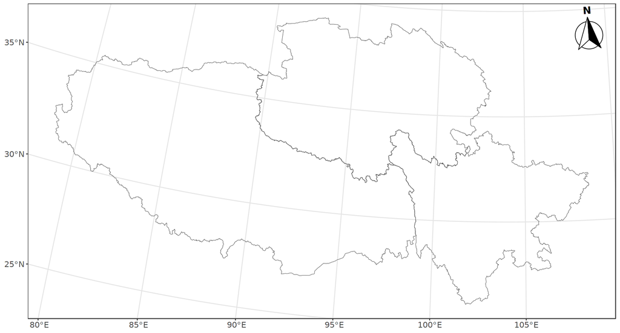

```r
# Plot the map of Xizang, Qinghai and Sichuan
options(repr.plot.width = 13.43, repr.plot.height = 7.23)
cn.map.sub %>% plot_bmap() %>% add_north_arrow() %>% add_crs()
```

Then, we use the map data of Qinghai-Tibet Plateau loaded from a local ESRI Shapefile as an example.

```r
# Read the original map of Qinghai-Tibet Plateau (QTP)
qtp.map <- system.file("shapefiles/qtp-map", "DBATP_Polygon.shp", package = "microgeo") %>% read_shp_map()
head(qtp.map@data)
```

A data.frame: 1 × 1

|  | Area <dbl> |
| --- | --- |
| 0 | 2542298 |

```r
# Add a column to meet the demands of trans_map_fmt() function
qtp.map@data$NAME <- "Qinghai-Tibet Plateau"
head(qtp.map@data)
```

A data.frame: 1 × 2

|  | Area <dbl> | NAME <chr> |
| --- | --- | --- |
| 0 | 2542298 | Qinghai-Tibet Plateau |

```r
# Convert the non-standardized SpatialPolygonsDataFrame to a microgeo-compatible one
qtp.map %<>% trans_map_fmt(var = 'NAME')
head(qtp.map@data)
```

A data.frame: 1 × 5

|  | TYPE <chr> | FMTS <chr> | NAME <chr> | X.CENTER <dbl> | Y.CENTER <dbl> |
| --- | --- | --- | --- | --- | --- |
| 0 | Non.DataV.GeoAtlas | microgeo | Qinghai-Tibet Plateau | 91.56316 | 33.54207 |

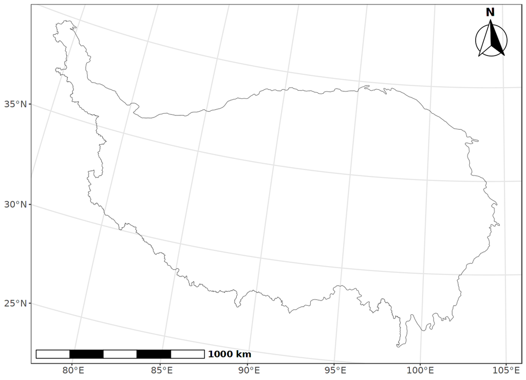

```r
# Plot the map of Qinghai-Tibet Plateau
options(repr.plot.width = 10, repr.plot.height = 7.23)
qtp.map %>% plot_bmap() %>% add_north_arrow() %>% add_scale_bar() %>% add_crs()
```

## Format the SpatialPolygonsDataFrame

Because there are a wide variety of contents in the SpatialPolygonsDataFrame retruned by `read_gadm_map()` and `read_shp_map()`, especially the `read_shp_map()`, we have implemented a function of `trans_map_fmt()` to convert a non-standardized SpatialPolygonsDataFrame to a microgeo-compatible one. Please note that this function **CAN NOT** accept the SpatialPolygonsDataFrame returned by `read_aliyun_map()`, which is already a microgeo-compatible one. The `trans_map_fmt()` requires a character that can indicate the name of each polygon in the formatted SpatialPolygonsDataFrame. We can use this function to convert any SpatialPolygonsDataFrame to a microgeo-compatible one, not limited to that generated by `read_gadm_map()` and `read_shp_map()`.

Actually, we have already applied the function of `trans_map_fmt()` in the above sections, so here we just provide a very simple example.

```r
# Read the map areas from local shapefiles
cn.map <- system.file("shapefiles/china-map", "china.shp", package = "microgeo") %>% read_shp_map()
cn.map.sub <- raster::subset(cn.map, cn.map$FENAME %in% c("Xizang Zizhiqu", "Qinghai Sheng", "Sichuan Sheng"))
head(cn.map.sub@data)
```

A data.frame: 3 × 9

|  | AREA <dbl> | BOUND_A_ <int> | BOUND_A_ID <int> | FCNAME <chr> | FENAME <chr> | NAME <chr> | OWNER <chr> | PERIMETER <dbl> | SOC <chr> |
| --- | --- | --- | --- | --- | --- | --- | --- | --- | --- |
| 92 | 69.3981 | 412 | 418 | 青海省 | Qinghai Sheng | NA | 青海省 | 63.5516 | CHN |
| 220 | 114.2030 | 725 | 721 | 西藏自治区 | Xizang Zizhiqu | NA | 西藏自治区 | 78.2912 | CHN |
| 265 | 45.7347 | 1144 | 1138 | 四川省 | Sichuan Sheng | NA | 四川省 | 60.2137 | CHN |

```r
# Convert the format of SpatialPolygonsDataFrame
cn.map.sub %<>% trans_map_fmt(var = 'FENAME')
head(cn.map.sub@data)
```

A data.frame: 3 × 5

|  | TYPE <chr> | FMTS <chr> | NAME <chr> | X.CENTER <dbl> | Y.CENTER <dbl> |
| --- | --- | --- | --- | --- | --- |
| 92 | Non.DataV.GeoAtlas | microgeo | Qinghai Sheng | 96.03758 | 35.67091 |
| 220 | Non.DataV.GeoAtlas | microgeo | Xizang Zizhiqu | 88.44232 | 31.49123 |
| 265 | Non.DataV.GeoAtlas | microgeo | Sichuan Sheng | 102.69251 | 30.62964 |

## Add grids to a SpatialPolygonsDataFrame

In some case, it is very unreliable to use the naive polygons (e.g., administrative divisions) in analyzing the biogeographic patterns of microbial traits. For example, the samples are unevenly distributed within the study area or are not collected based on a grid sampling method. To solve such a problem, we have designed a function of `grid_map()`, which can grid the study areas based on a given spatial resolution (degree). That is, the map of the whole study area can be divided into grids uniformly by using this function. The SpatialPolygonsDataFrame returned by the function of `grid_map()` can be used for subsequently grid-based statistical analysis and visualization.

```r
# Read map from the DataV.GeoAtlas (`http://datav.aliyun.com/portal/school/atlas/area_selector`)
map <- read_aliyun_map(adcode = c("540000", "630000", "510000"))
head(map@data)
```

A data.frame: 3 × 5

|  | TYPE <chr> | FMTS <chr> | NAME <chr> | X.CENTER <dbl> | Y.CENTER <dbl> |
| --- | --- | --- | --- | --- | --- |
| 1 | DataV.GeoAtlas | microgeo | 西藏自治区 | 88.38828 | 31.56375 |
| 2 | DataV.GeoAtlas | microgeo | 青海省 | 96.04353 | 35.72640 |
| 3 | DataV.GeoAtlas | microgeo | 四川省 | 102.69345 | 30.67454 |

```r
# Grid the map using a spatial resolution of 1.5
gridded.map <- grid_map(map = map, res = 1.5) %>% suppressMessages()
head(gridded.map@data)
```

A data.frame: 6 × 5

|  | TYPE <chr> | FMTS <chr> | NAME <chr> | X.CENTER <dbl> | Y.CENTER <dbl> |
| --- | --- | --- | --- | --- | --- |
| 1 | Gridded.Map | microgeo | 1 | 83.74702 | 29.73742 |
| 2 | Gridded.Map | microgeo | 2 | 85.46302 | 28.50944 |
| 3 | Gridded.Map | microgeo | 3 | 86.67299 | 28.33105 |
| 4 | Gridded.Map | microgeo | 4 | 89.49169 | 28.25211 |
| 5 | Gridded.Map | microgeo | 5 | 88.12468 | 28.29693 |
| 6 | Gridded.Map | microgeo | 6 | 85.14919 | 29.46224 |

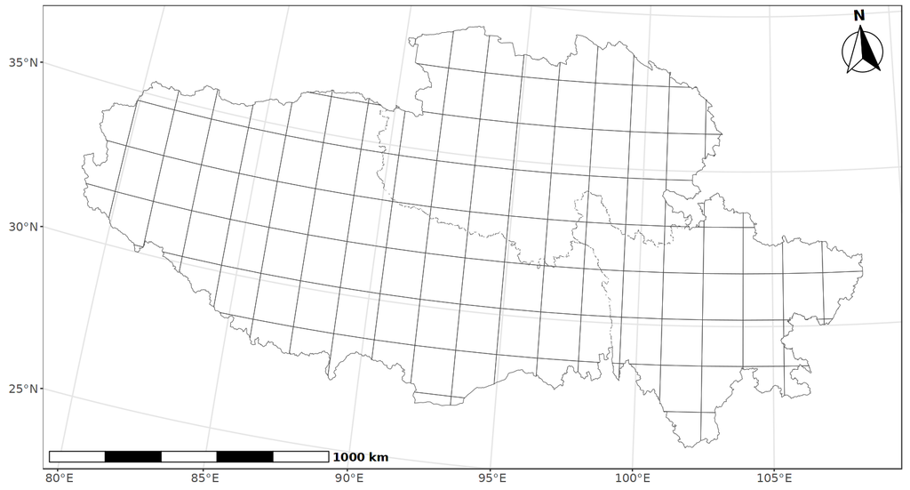

```r
# Plot the gridded map without grid names
options(repr.plot.width = 13.43, repr.plot.height = 7.23)
gridded.map %>% plot_bmap() %>% add_north_arrow() %>% add_scale_bar() %>% add_crs() %>% suppressMessages()
```

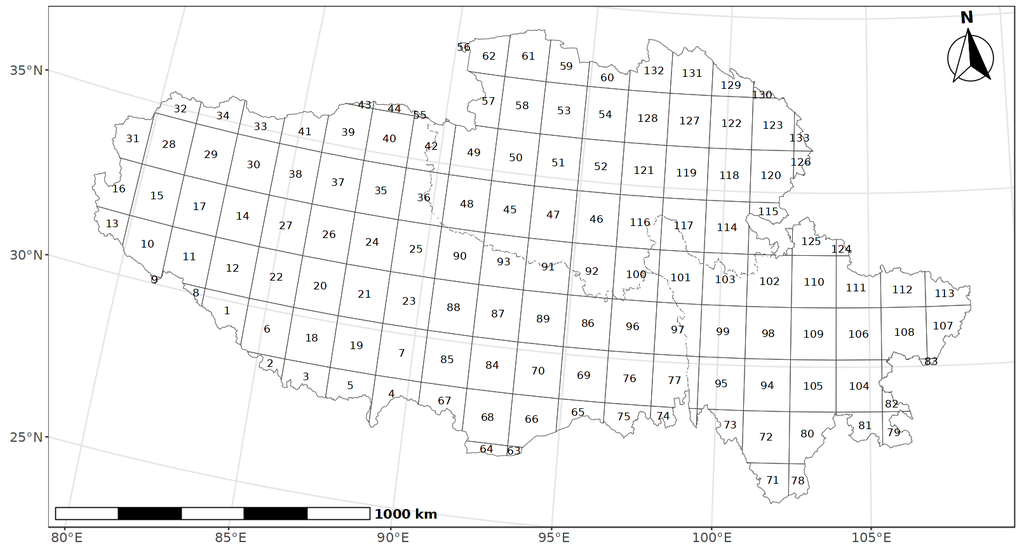

```r
# Plot the gridded map with grid names
options(repr.plot.width = 13.43, repr.plot.height = 7.23)
gridded.map %>% plot_bmap() %>%
    add_label(dat = gridded.map@data, lab.var = "NAME", lon.var = "X.CENTER", lat.var = "Y.CENTER", size = 3.5) %>%
    add_north_arrow() %>% add_scale_bar() %>% add_crs() %>% suppressMessages()
```